# Risk Factor Analysis

## Outcome Variable

**Outcome Variable:** stunted

## Predictor Variables

**Intervention Variable:** rain_quartile

**Adjustment Set:**

unadjusted

## Stratifying Variables

The analysis was stratified on these variable(s):

- studyid
- country
- agecat

## Data Summary

| studyid | country | agecat | rain_quartile | stunted | n_cell | n | outcome_variable |
| --- | --- | --- | --- | --- | --- | --- | --- |
| CMC-V-BCS-2002 | India | Birth | 1 | 0 | 14 | 92 | stunted |
| CMC-V-BCS-2002 | India | Birth | 1 | 1 | 4 | 92 | stunted |
| CMC-V-BCS-2002 | India | Birth | 2 | 0 | 20 | 92 | stunted |
| CMC-V-BCS-2002 | India | Birth | 2 | 1 | 5 | 92 | stunted |
| CMC-V-BCS-2002 | India | Birth | 3 | 0 | 26 | 92 | stunted |
| CMC-V-BCS-2002 | India | Birth | 3 | 1 | 4 | 92 | stunted |
| CMC-V-BCS-2002 | India | Birth | 4 | 0 | 15 | 92 | stunted |
| CMC-V-BCS-2002 | India | Birth | 4 | 1 | 4 | 92 | stunted |
| CMC-V-BCS-2002 | India | 6 months | 1 | 0 | 60 | 369 | stunted |
| CMC-V-BCS-2002 | India | 6 months | 1 | 1 | 41 | 369 | stunted |
| CMC-V-BCS-2002 | India | 6 months | 2 | 0 | 81 | 369 | stunted |
| CMC-V-BCS-2002 | India | 6 months | 2 | 1 | 30 | 369 | stunted |
| CMC-V-BCS-2002 | India | 6 months | 3 | 0 | 75 | 369 | stunted |
| CMC-V-BCS-2002 | India | 6 months | 3 | 1 | 22 | 369 | stunted |
| CMC-V-BCS-2002 | India | 6 months | 4 | 0 | 42 | 369 | stunted |
| CMC-V-BCS-2002 | India | 6 months | 4 | 1 | 18 | 369 | stunted |
| CMC-V-BCS-2002 | India | 24 months | 1 | 0 | 29 | 371 | stunted |
| CMC-V-BCS-2002 | India | 24 months | 1 | 1 | 72 | 371 | stunted |
| CMC-V-BCS-2002 | India | 24 months | 2 | 0 | 29 | 371 | stunted |
| CMC-V-BCS-2002 | India | 24 months | 2 | 1 | 70 | 371 | stunted |
| CMC-V-BCS-2002 | India | 24 months | 3 | 0 | 34 | 371 | stunted |
| CMC-V-BCS-2002 | India | 24 months | 3 | 1 | 82 | 371 | stunted |
| CMC-V-BCS-2002 | India | 24 months | 4 | 0 | 13 | 371 | stunted |
| CMC-V-BCS-2002 | India | 24 months | 4 | 1 | 42 | 371 | stunted |
| CMIN | Bangladesh | Birth | 1 | 0 | 3 | 26 | stunted |
| CMIN | Bangladesh | Birth | 1 | 1 | 4 | 26 | stunted |
| CMIN | Bangladesh | Birth | 2 | 0 | 5 | 26 | stunted |
| CMIN | Bangladesh | Birth | 2 | 1 | 1 | 26 | stunted |
| CMIN | Bangladesh | Birth | 3 | 0 | 5 | 26 | stunted |
| CMIN | Bangladesh | Birth | 3 | 1 | 1 | 26 | stunted |

[output cut: 506 more lines]

The following strata were considered:

- studyid: CMC-V-BCS-2002, country: India, agecat: 24 months
- studyid: CMC-V-BCS-2002, country: India, agecat: 6 months
- studyid: CMC-V-BCS-2002, country: India, agecat: Birth
- studyid: CMIN, country: Bangladesh, agecat: 24 months
- studyid: CMIN, country: Bangladesh, agecat: 6 months
- studyid: CMIN, country: Bangladesh, agecat: Birth
- studyid: CONTENT, country: Peru, agecat: 24 months
- studyid: CONTENT, country: Peru, agecat: 6 months
- studyid: CONTENT, country: Peru, agecat: Birth
- studyid: EE, country: Pakistan, agecat: 24 months
- studyid: EE, country: Pakistan, agecat: 6 months
- studyid: EE, country: Pakistan, agecat: Birth
- studyid: GMS-Nepal, country: Nepal, agecat: 24 months
- studyid: GMS-Nepal, country: Nepal, agecat: 6 months
- studyid: GMS-Nepal, country: Nepal, agecat: Birth
- studyid: Guatemala BSC, country: Guatemala, agecat: 6 months
- studyid: IRC, country: India, agecat: 24 months
- studyid: IRC, country: India, agecat: 6 months
- studyid: IRC, country: India, agecat: Birth
- studyid: JiVitA-3, country: Bangladesh, agecat: 24 months
- studyid: JiVitA-3, country: Bangladesh, agecat: 6 months
- studyid: JiVitA-3, country: Bangladesh, agecat: Birth
- studyid: JiVitA-4, country: Bangladesh, agecat: 24 months
- studyid: JiVitA-4, country: Bangladesh, agecat: 6 months
- studyid: JiVitA-4, country: Bangladesh, agecat: Birth
- studyid: Keneba, country: Gambia, agecat: 24 months
- studyid: Keneba, country: Gambia, agecat: 6 months
- studyid: Keneba, country: Gambia, agecat: Birth
- studyid: LCNI-5, country: Malawi, agecat: 24 months
- studyid: LCNI-5, country: Malawi, agecat: 6 months
- studyid: MAL-ED, country: Bangladesh, agecat: 24 months
- studyid: MAL-ED, country: Bangladesh, agecat: 6 months
- studyid: MAL-ED, country: Bangladesh, agecat: Birth
- studyid: MAL-ED, country: Brazil, agecat: 24 months
- studyid: MAL-ED, country: Brazil, agecat: 6 months
- studyid: MAL-ED, country: Brazil, agecat: Birth
- studyid: MAL-ED, country: India, agecat: 24 months
- studyid: MAL-ED, country: India, agecat: 6 months
- studyid: MAL-ED, country: India, agecat: Birth
- studyid: MAL-ED, country: Nepal, agecat: 24 months
- studyid: MAL-ED, country: Nepal, agecat: 6 months
- studyid: MAL-ED, country: Nepal, agecat: Birth
- studyid: MAL-ED, country: Peru, agecat: 24 months
- studyid: MAL-ED, country: Peru, agecat: 6 months
- studyid: MAL-ED, country: Peru, agecat: Birth
- studyid: MAL-ED, country: South Africa, agecat: 24 months
- studyid: MAL-ED, country: South Africa, agecat: 6 months
- studyid: MAL-ED, country: South Africa, agecat: Birth
- studyid: MAL-ED, country: Tanzania, agecat: 24 months
- studyid: MAL-ED, country: Tanzania, agecat: 6 months
- studyid: MAL-ED, country: Tanzania, agecat: Birth
- studyid: PROBIT, country: Belarus, agecat: 24 months
- studyid: PROBIT, country: Belarus, agecat: 6 months
- studyid: PROBIT, country: Belarus, agecat: Birth
- studyid: PROVIDE, country: Bangladesh, agecat: 24 months
- studyid: PROVIDE, country: Bangladesh, agecat: 6 months
- studyid: PROVIDE, country: Bangladesh, agecat: Birth
- studyid: ResPak, country: Pakistan, agecat: 6 months
- studyid: ResPak, country: Pakistan, agecat: Birth
- studyid: SAS-CompFeed, country: India, agecat: 6 months
- studyid: SAS-CompFeed, country: India, agecat: Birth
- studyid: SAS-FoodSuppl, country: India, agecat: 6 months
- studyid: TanzaniaChild2, country: Tanzania, agecat: 24 months
- studyid: TanzaniaChild2, country: Tanzania, agecat: 6 months
- studyid: ZVITAMBO, country: Zimbabwe, agecat: 24 months
- studyid: ZVITAMBO, country: Zimbabwe, agecat: 6 months
- studyid: ZVITAMBO, country: Zimbabwe, agecat: Birth

### Dropped Strata

Some strata were dropped due to rare outcomes:

- studyid: CMC-V-BCS-2002, country: India, agecat: Birth
- studyid: CMIN, country: Bangladesh, agecat: Birth
- studyid: CONTENT, country: Peru, agecat: Birth
- studyid: CONTENT, country: Peru, agecat: 6 months
- studyid: CONTENT, country: Peru, agecat: 24 months
- studyid: EE, country: Pakistan, agecat: Birth
- studyid: EE, country: Pakistan, agecat: 6 months
- studyid: EE, country: Pakistan, agecat: 24 months
- studyid: GMS-Nepal, country: Nepal, agecat: Birth
- studyid: GMS-Nepal, country: Nepal, agecat: 6 months
- studyid: GMS-Nepal, country: Nepal, agecat: 24 months
- studyid: MAL-ED, country: Brazil, agecat: Birth
- studyid: MAL-ED, country: Brazil, agecat: 6 months
- studyid: MAL-ED, country: Brazil, agecat: 24 months
- studyid: MAL-ED, country: India, agecat: Birth
- studyid: MAL-ED, country: Nepal, agecat: Birth
- studyid: MAL-ED, country: Nepal, agecat: 6 months
- studyid: MAL-ED, country: Nepal, agecat: 24 months
- studyid: MAL-ED, country: Peru, agecat: Birth
- studyid: MAL-ED, country: South Africa, agecat: Birth
- studyid: MAL-ED, country: South Africa, agecat: 6 months
- studyid: ResPak, country: Pakistan, agecat: Birth
- studyid: ResPak, country: Pakistan, agecat: 6 months
- studyid: TanzaniaChild2, country: Tanzania, agecat: 24 months

## Methods Detail

We’re interested in the causal parameters $E[Y_a]$ for all values of $a \in \mathcal{A}$. These parameters represent the mean outcome if, possibly contrary to fact, we intervened to set all units to have $A=a$. Under the randomization and positivity assumptions, these are identified by the statistical parameters $\psi_a=E_W[E_{Y|A,W}(Y|A=a,W)]$. In addition, we’re interested in the mean of $Y$, $E[Y]$ under no intervention (the observed mean). We will estimate these parameters by using SuperLearner to fit the relevant likelihood factors – $E_{Y|A,W}(Y|A=a,W)$ and $p(A=a|W)$, and then updating our likelihood fit using a joint TMLE.

For unadjusted analyses ($W=\{\}$), initial likelihoods were estimated using Lrnr_glm to estimate the simple $E(Y|A)$ and Lrnr_mean to estimate $p(A)$. For adjusted analyses, a small library containing Lrnr_glmnet, Lrnr_xgboost, and Lrnr_mean was used.

Having estimated these parameters, we will then use the delta method to estimate relative risks and attributable risks relative to a prespecified baseline level of $A$.

# Results Detail

## Results Plots

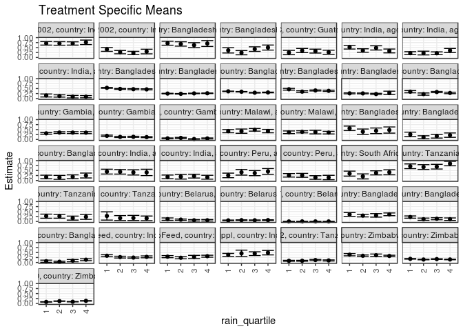

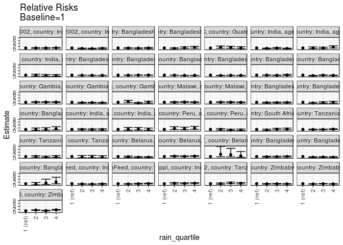

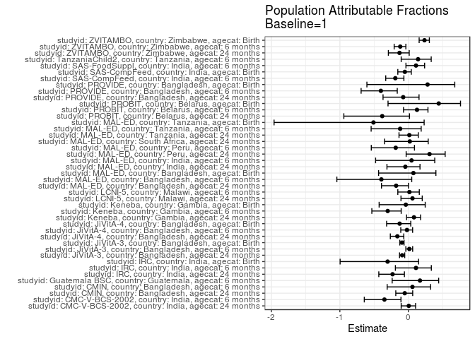

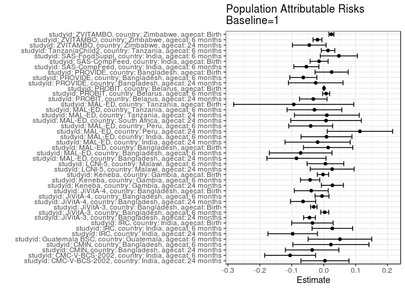

## Results Table

### Parameter: TSM

| studyid | country | agecat | intervention_level | baseline_level | estimate | ci_lower | ci_upper |
| --- | --- | --- | --- | --- | --- | --- | --- |
| CMC-V-BCS-2002 | India | 6 months | 1 | NA | 0.4059406 | 0.3100397 | 0.5018415 |
| CMC-V-BCS-2002 | India | 6 months | 2 | NA | 0.2702703 | 0.1875416 | 0.3529989 |
| CMC-V-BCS-2002 | India | 6 months | 3 | NA | 0.2268041 | 0.1433550 | 0.3102532 |
| CMC-V-BCS-2002 | India | 6 months | 4 | NA | 0.3000000 | 0.1838895 | 0.4161105 |
| CMC-V-BCS-2002 | India | 24 months | 1 | NA | 0.7128713 | 0.6245191 | 0.8012235 |
| CMC-V-BCS-2002 | India | 24 months | 2 | NA | 0.7070707 | 0.6173011 | 0.7968403 |
| CMC-V-BCS-2002 | India | 24 months | 3 | NA | 0.7068966 | 0.6239509 | 0.7898422 |
| CMC-V-BCS-2002 | India | 24 months | 4 | NA | 0.7636364 | 0.6512053 | 0.8760675 |
| CMIN | Bangladesh | 6 months | 1 | NA | 0.3600000 | 0.2266786 | 0.4933214 |
| CMIN | Bangladesh | 6 months | 2 | NA | 0.2419355 | 0.1351160 | 0.3487550 |
| CMIN | Bangladesh | 6 months | 3 | NA | 0.4225352 | 0.3073999 | 0.5376705 |
| CMIN | Bangladesh | 6 months | 4 | NA | 0.5000000 | 0.3732237 | 0.6267763 |
| CMIN | Bangladesh | 24 months | 1 | NA | 0.7179487 | 0.6178772 | 0.8180203 |
| CMIN | Bangladesh | 24 months | 2 | NA | 0.6811594 | 0.5709715 | 0.7913473 |
| CMIN | Bangladesh | 24 months | 3 | NA | 0.6206897 | 0.4955578 | 0.7458215 |
| CMIN | Bangladesh | 24 months | 4 | NA | 0.7027027 | 0.5551226 | 0.8502828 |
| Guatemala BSC | Guatemala | 6 months | 1 | NA | 0.2500000 | 0.1402510 | 0.3597490 |
| Guatemala BSC | Guatemala | 6 months | 2 | NA | 0.3500000 | 0.2453061 | 0.4546939 |
| Guatemala BSC | Guatemala | 6 months | 3 | NA | 0.3218391 | 0.2235055 | 0.4201726 |
| Guatemala BSC | Guatemala | 6 months | 4 | NA | 0.2638889 | 0.1619144 | 0.3658634 |
| IRC | India | Birth | 1 | NA | 0.1511628 | 0.0753585 | 0.2269671 |
| IRC | India | Birth | 2 | NA | 0.1269841 | 0.0687726 | 0.1851957 |
| IRC | India | Birth | 3 | NA | 0.0909091 | 0.0266151 | 0.1552031 |
| IRC | India | Birth | 4 | NA | 0.0909091 | 0.0342071 | 0.1476111 |
| IRC | India | 6 months | 1 | NA | 0.2184874 | 0.1441530 | 0.2928218 |
| IRC | India | 6 months | 2 | NA | 0.2236842 | 0.1298822 | 0.3174863 |
| IRC | India | 6 months | 3 | NA | 0.2125984 | 0.1413527 | 0.2838441 |
| IRC | India | 6 months | 4 | NA | 0.3529412 | 0.2512236 | 0.4546587 |
| IRC | India | 24 months | 1 | NA | 0.5175439 | 0.4257043 | 0.6093834 |
| IRC | India | 24 months | 2 | NA | 0.3529412 | 0.2669747 | 0.4389077 |

[output cut: 142 more lines]

### Parameter: E(Y)

| studyid | country | agecat | intervention_level | baseline_level | estimate | ci_lower | ci_upper |
| --- | --- | --- | --- | --- | --- | --- | --- |
| CMC-V-BCS-2002 | India | 6 months | NA | NA | 0.3008130 | 0.2539566 | 0.3476694 |
| CMC-V-BCS-2002 | India | 24 months | NA | NA | 0.7169811 | 0.6710815 | 0.7628807 |
| CMIN | Bangladesh | 6 months | NA | NA | 0.3827160 | 0.3214780 | 0.4439541 |
| CMIN | Bangladesh | 24 months | NA | NA | 0.6818182 | 0.6230135 | 0.7406228 |
| Guatemala BSC | Guatemala | 6 months | NA | NA | 0.3010033 | 0.2489243 | 0.3530824 |
| IRC | India | Birth | NA | NA | 0.1159794 | 0.0840777 | 0.1478811 |
| IRC | India | 6 months | NA | NA | 0.2457002 | 0.2038248 | 0.2875757 |
| IRC | India | 24 months | NA | NA | 0.4205379 | 0.3726382 | 0.4684376 |
| JiVitA-3 | Bangladesh | Birth | NA | NA | 0.3289690 | 0.3216017 | 0.3363364 |
| JiVitA-3 | Bangladesh | 6 months | NA | NA | 0.2513830 | 0.2432594 | 0.2595066 |
| JiVitA-3 | Bangladesh | 24 months | NA | NA | 0.4910207 | 0.4779080 | 0.5041335 |
| JiVitA-4 | Bangladesh | Birth | NA | NA | 0.3035778 | 0.2836422 | 0.3235133 |
| JiVitA-4 | Bangladesh | 6 months | NA | NA | 0.2527427 | 0.2386864 | 0.2667990 |
| JiVitA-4 | Bangladesh | 24 months | NA | NA | 0.4008838 | 0.3839145 | 0.4178532 |
| Keneba | Gambia | Birth | NA | NA | 0.0537913 | 0.0425309 | 0.0650518 |
| Keneba | Gambia | 6 months | NA | NA | 0.1407372 | 0.1258213 | 0.1556531 |
| Keneba | Gambia | 24 months | NA | NA | 0.3368116 | 0.3145020 | 0.3591212 |
| LCNI-5 | Malawi | 6 months | NA | NA | 0.3682956 | 0.3356382 | 0.4009530 |
| LCNI-5 | Malawi | 24 months | NA | NA | 0.4455959 | 0.4050760 | 0.4861157 |
| MAL-ED | Bangladesh | Birth | NA | NA | 0.1904762 | 0.1397281 | 0.2412242 |
| MAL-ED | Bangladesh | 6 months | NA | NA | 0.1825726 | 0.1336978 | 0.2314474 |
| MAL-ED | Bangladesh | 24 months | NA | NA | 0.4764151 | 0.4090254 | 0.5438047 |
| MAL-ED | India | 6 months | NA | NA | 0.1906780 | 0.1404524 | 0.2409036 |
| MAL-ED | India | 24 months | NA | NA | 0.4273128 | 0.3628178 | 0.4918077 |
| MAL-ED | Peru | 6 months | NA | NA | 0.2197802 | 0.1705687 | 0.2689917 |
| MAL-ED | Peru | 24 months | NA | NA | 0.3681592 | 0.3013164 | 0.4350020 |
| MAL-ED | South Africa | 24 months | NA | NA | 0.3529412 | 0.2921001 | 0.4137823 |
| MAL-ED | Tanzania | Birth | NA | NA | 0.1840000 | 0.1157989 | 0.2522011 |
| MAL-ED | Tanzania | 6 months | NA | NA | 0.2388664 | 0.1855834 | 0.2921494 |
| MAL-ED | Tanzania | 24 months | NA | NA | 0.7242991 | 0.6642873 | 0.7843108 |
| PROBIT | Belarus | Birth | NA | NA | 0.0023758 | 0.0010936 | 0.0036580 |
| PROBIT | Belarus | 6 months | NA | NA | 0.0626864 | 0.0488489 | 0.0765238 |
| PROBIT | Belarus | 24 months | NA | NA | 0.0852540 | 0.0554439 | 0.1150642 |
| PROVIDE | Bangladesh | Birth | NA | NA | 0.0890538 | 0.0649864 | 0.1131212 |
| PROVIDE | Bangladesh | 6 months | NA | NA | 0.1589404 | 0.1297581 | 0.1881227 |
| PROVIDE | Bangladesh | 24 months | NA | NA | 0.3287197 | 0.2903909 | 0.3670485 |
| SAS-CompFeed | India | Birth | NA | NA | 0.2787540 | 0.2475949 | 0.3099131 |
| SAS-CompFeed | India | 6 months | NA | NA | 0.2844311 | 0.2666491 | 0.3022132 |
| SAS-FoodSuppl | India | 6 months | NA | NA | 0.4289474 | 0.3791199 | 0.4787748 |
| TanzaniaChild2 | Tanzania | 6 months | NA | NA | 0.0970922 | 0.0842059 | 0.1099785 |
| ZVITAMBO | Zimbabwe | Birth | NA | NA | 0.1033514 | 0.0982859 | 0.1084168 |
| ZVITAMBO | Zimbabwe | 6 months | NA | NA | 0.1628792 | 0.1551057 | 0.1706527 |
| ZVITAMBO | Zimbabwe | 24 months | NA | NA | 0.3469512 | 0.3239068 | 0.3699956 |

### Parameter: RR

| studyid | country | agecat | intervention_level | baseline_level | estimate | ci_lower | ci_upper |
| --- | --- | --- | --- | --- | --- | --- | --- |
| CMC-V-BCS-2002 | India | 6 months | 1 | 1 | 1.0000000 | 1.0000000 | 1.0000000 |
| CMC-V-BCS-2002 | India | 6 months | 2 | 1 | 0.6657877 | 0.4522843 | 0.9800767 |
| CMC-V-BCS-2002 | India | 6 months | 3 | 1 | 0.5587126 | 0.3608224 | 0.8651342 |
| CMC-V-BCS-2002 | India | 6 months | 4 | 1 | 0.7390244 | 0.4696049 | 1.1630140 |
| CMC-V-BCS-2002 | India | 24 months | 1 | 1 | 1.0000000 | 1.0000000 | 1.0000000 |
| CMC-V-BCS-2002 | India | 24 months | 2 | 1 | 0.9918631 | 0.8306099 | 1.1844217 |
| CMC-V-BCS-2002 | India | 24 months | 3 | 1 | 0.9916188 | 0.8360320 | 1.1761605 |
| CMC-V-BCS-2002 | India | 24 months | 4 | 1 | 1.0712121 | 0.8836792 | 1.2985430 |
| CMIN | Bangladesh | 6 months | 1 | 1 | 1.0000000 | 1.0000000 | 1.0000000 |
| CMIN | Bangladesh | 6 months | 2 | 1 | 0.6720430 | 0.3776809 | 1.1958290 |
| CMIN | Bangladesh | 6 months | 3 | 1 | 1.1737089 | 0.7411054 | 1.8588350 |
| CMIN | Bangladesh | 6 months | 4 | 1 | 1.3888889 | 0.8866412 | 2.1756404 |
| CMIN | Bangladesh | 24 months | 1 | 1 | 1.0000000 | 1.0000000 | 1.0000000 |
| CMIN | Bangladesh | 24 months | 2 | 1 | 0.9487578 | 0.7663360 | 1.1746040 |
| CMIN | Bangladesh | 24 months | 3 | 1 | 0.8645320 | 0.6766091 | 1.1046491 |
| CMIN | Bangladesh | 24 months | 4 | 1 | 0.9787645 | 0.7606916 | 1.2593538 |
| Guatemala BSC | Guatemala | 6 months | 1 | 1 | 1.0000000 | 1.0000000 | 1.0000000 |
| Guatemala BSC | Guatemala | 6 months | 2 | 1 | 1.4000000 | 0.8230432 | 2.3814060 |
| Guatemala BSC | Guatemala | 6 months | 3 | 1 | 1.2873563 | 0.7540743 | 2.1977758 |
| Guatemala BSC | Guatemala | 6 months | 4 | 1 | 1.0555556 | 0.5881465 | 1.8944218 |
| IRC | India | Birth | 1 | 1 | 1.0000000 | 1.0000000 | 1.0000000 |
| IRC | India | Birth | 2 | 1 | 0.8400488 | 0.4258267 | 1.6572048 |
| IRC | India | Birth | 3 | 1 | 0.6013986 | 0.2527186 | 1.4311582 |
| IRC | India | Birth | 4 | 1 | 0.6013986 | 0.2701404 | 1.3388602 |
| IRC | India | 6 months | 1 | 1 | 1.0000000 | 1.0000000 | 1.0000000 |
| IRC | India | 6 months | 2 | 1 | 1.0237854 | 0.5966056 | 1.7568332 |
| IRC | India | 6 months | 3 | 1 | 0.9730466 | 0.6035807 | 1.5686713 |
| IRC | India | 6 months | 4 | 1 | 1.6153846 | 1.0342651 | 2.5230161 |
| IRC | India | 24 months | 1 | 1 | 1.0000000 | 1.0000000 | 1.0000000 |
| IRC | India | 24 months | 2 | 1 | 0.6819541 | 0.5045184 | 0.9217928 |

[output cut: 142 more lines]

### Parameter: PAR

| studyid | country | agecat | intervention_level | baseline_level | estimate | ci_lower | ci_upper |
| --- | --- | --- | --- | --- | --- | --- | --- |
| CMC-V-BCS-2002 | India | 6 months | 1 | NA | -0.1051276 | -0.1848637 | -0.0253915 |
| CMC-V-BCS-2002 | India | 24 months | 1 | NA | 0.0041098 | -0.0711408 | 0.0793605 |
| CMIN | Bangladesh | 6 months | 1 | NA | 0.0227160 | -0.0964898 | 0.1419219 |
| CMIN | Bangladesh | 24 months | 1 | NA | -0.0361305 | -0.1198968 | 0.0476358 |
| Guatemala BSC | Guatemala | 6 months | 1 | NA | 0.0510033 | -0.0486110 | 0.1506177 |
| IRC | India | Birth | 1 | NA | -0.0351834 | -0.1001194 | 0.0297526 |
| IRC | India | 6 months | 1 | NA | 0.0272129 | -0.0364108 | 0.0908365 |
| IRC | India | 24 months | 1 | NA | -0.0970060 | -0.1746398 | -0.0193721 |
| JiVitA-3 | Bangladesh | Birth | 1 | NA | -0.0308540 | -0.0409680 | -0.0207400 |
| JiVitA-3 | Bangladesh | 6 months | 1 | NA | 0.0035313 | -0.0089862 | 0.0160487 |
| JiVitA-3 | Bangladesh | 24 months | 1 | NA | -0.0443943 | -0.0629273 | -0.0258614 |
| JiVitA-4 | Bangladesh | Birth | 1 | NA | -0.0387646 | -0.0918708 | 0.0143416 |
| JiVitA-4 | Bangladesh | 6 months | 1 | NA | -0.0052559 | -0.0270343 | 0.0165224 |
| JiVitA-4 | Bangladesh | 24 months | 1 | NA | -0.0645340 | -0.1039201 | -0.0251480 |
| Keneba | Gambia | Birth | 1 | NA | -0.0020123 | -0.0197989 | 0.0157744 |
| Keneba | Gambia | 6 months | 1 | NA | -0.0424525 | -0.0726402 | -0.0122647 |
| Keneba | Gambia | 24 months | 1 | NA | 0.0274304 | -0.0069902 | 0.0618509 |
| LCNI-5 | Malawi | 6 months | 1 | NA | 0.0055505 | -0.0519412 | 0.0630422 |
| LCNI-5 | Malawi | 24 months | 1 | NA | 0.0266769 | -0.0421375 | 0.0954914 |
| MAL-ED | Bangladesh | Birth | 1 | NA | 0.0140056 | -0.0632370 | 0.0912482 |
| MAL-ED | Bangladesh | 6 months | 1 | NA | -0.0719728 | -0.1700686 | 0.0261229 |
| MAL-ED | Bangladesh | 24 months | 1 | NA | -0.0852287 | -0.1779318 | 0.0074744 |
| MAL-ED | India | 6 months | 1 | NA | 0.0088598 | -0.0708549 | 0.0885745 |
| MAL-ED | India | 24 months | 1 | NA | -0.0188411 | -0.1209560 | 0.0832739 |
| MAL-ED | Peru | 6 months | 1 | NA | -0.0406364 | -0.1093157 | 0.0280428 |
| MAL-ED | Peru | 24 months | 1 | NA | 0.1136137 | 0.0111532 | 0.2160743 |
| MAL-ED | South Africa | 24 months | 1 | NA | 0.0074866 | -0.1031080 | 0.1180813 |
| MAL-ED | Tanzania | Birth | 1 | NA | -0.0937778 | -0.2818768 | 0.0943212 |
| MAL-ED | Tanzania | 6 months | 1 | NA | -0.0287392 | -0.1145603 | 0.0570819 |
| MAL-ED | Tanzania | 24 months | 1 | NA | 0.0100134 | -0.0915021 | 0.1115288 |
| PROBIT | Belarus | Birth | 1 | NA | 0.0010531 | -0.0001184 | 0.0022245 |
| PROBIT | Belarus | 6 months | 1 | NA | 0.0078691 | -0.0031355 | 0.0188737 |
| PROBIT | Belarus | 24 months | 1 | NA | -0.0325542 | -0.0755129 | 0.0104046 |
| PROVIDE | Bangladesh | Birth | 1 | NA | 0.0249512 | -0.0268430 | 0.0767454 |
| PROVIDE | Bangladesh | 6 months | 1 | NA | -0.0638084 | -0.1062698 | -0.0213470 |
| PROVIDE | Bangladesh | 24 months | 1 | NA | -0.0248156 | -0.1103115 | 0.0606803 |
| SAS-CompFeed | India | Birth | 1 | NA | -0.0142863 | -0.0425403 | 0.0139677 |
| SAS-CompFeed | India | 6 months | 1 | NA | -0.0542355 | -0.0935259 | -0.0149451 |
| SAS-FoodSuppl | India | 6 months | 1 | NA | 0.0476974 | -0.0104353 | 0.1058300 |
| TanzaniaChild2 | Tanzania | 6 months | 1 | NA | 0.0137588 | -0.0073512 | 0.0348689 |
| ZVITAMBO | Zimbabwe | Birth | 1 | NA | 0.0243264 | 0.0165640 | 0.0320889 |
| ZVITAMBO | Zimbabwe | 6 months | 1 | NA | -0.0193594 | -0.0332576 | -0.0054612 |
| ZVITAMBO | Zimbabwe | 24 months | 1 | NA | -0.0449902 | -0.0976157 | 0.0076354 |

### Parameter: PAF

| studyid | country | agecat | intervention_level | baseline_level | estimate | ci_lower | ci_upper |
| --- | --- | --- | --- | --- | --- | --- | --- |
| CMC-V-BCS-2002 | India | 6 months | 1 | NA | -0.3494782 | -0.6434663 | -0.1080795 |
| CMC-V-BCS-2002 | India | 24 months | 1 | NA | 0.0057322 | -0.1049652 | 0.1053397 |
| CMIN | Bangladesh | 6 months | 1 | NA | 0.0593548 | -0.3099169 | 0.3245272 |
| CMIN | Bangladesh | 24 months | 1 | NA | -0.0529915 | -0.1836381 | 0.0632348 |
| Guatemala BSC | Guatemala | 6 months | 1 | NA | 0.1694444 | -0.2365826 | 0.4421541 |
| IRC | India | Birth | 1 | NA | -0.3033592 | -0.9964508 | 0.1491174 |
| IRC | India | 6 months | 1 | NA | 0.1107563 | -0.1894501 | 0.3351933 |
| IRC | India | 24 months | 1 | NA | -0.2306712 | -0.4315444 | -0.0579843 |
| JiVitA-3 | Bangladesh | Birth | 1 | NA | -0.0937900 | -0.1251914 | -0.0632650 |
| JiVitA-3 | Bangladesh | 6 months | 1 | NA | 0.0140473 | -0.0370141 | 0.0625945 |
| JiVitA-3 | Bangladesh | 24 months | 1 | NA | -0.0904124 | -0.1289500 | -0.0531902 |
| JiVitA-4 | Bangladesh | Birth | 1 | NA | -0.1276925 | -0.3174435 | 0.0347288 |
| JiVitA-4 | Bangladesh | 6 months | 1 | NA | -0.0207956 | -0.1108791 | 0.0619829 |
| JiVitA-4 | Bangladesh | 24 months | 1 | NA | -0.1609794 | -0.2635263 | -0.0667551 |
| Keneba | Gambia | Birth | 1 | NA | -0.0374086 | -0.4267277 | 0.2456749 |
| Keneba | Gambia | 6 months | 1 | NA | -0.3016435 | -0.5332106 | -0.1050510 |
| Keneba | Gambia | 24 months | 1 | NA | 0.0814412 | -0.0266450 | 0.1781481 |
| LCNI-5 | Malawi | 6 months | 1 | NA | 0.0150708 | -0.1540830 | 0.1594317 |
| LCNI-5 | Malawi | 24 months | 1 | NA | 0.0598680 | -0.1080303 | 0.2023249 |
| MAL-ED | Bangladesh | Birth | 1 | NA | 0.0735294 | -0.4348307 | 0.4017777 |
| MAL-ED | Bangladesh | 6 months | 1 | NA | -0.3942149 | -1.0439686 | 0.0489897 |
| MAL-ED | Bangladesh | 24 months | 1 | NA | -0.1788960 | -0.3926746 | 0.0020672 |
| MAL-ED | India | 6 months | 1 | NA | 0.0464646 | -0.4780866 | 0.3848604 |
| MAL-ED | India | 24 months | 1 | NA | -0.0440920 | -0.3126861 | 0.1695440 |
| MAL-ED | Peru | 6 months | 1 | NA | -0.1848958 | -0.5412792 | 0.0890826 |
| MAL-ED | Peru | 24 months | 1 | NA | 0.3085995 | -0.0324138 | 0.5369738 |
| MAL-ED | South Africa | 24 months | 1 | NA | 0.0212121 | -0.3481100 | 0.2893564 |
| MAL-ED | Tanzania | Birth | 1 | NA | -0.5096618 | -1.9604511 | 0.2301583 |
| MAL-ED | Tanzania | 6 months | 1 | NA | -0.1203151 | -0.5434871 | 0.1868374 |
| MAL-ED | Tanzania | 24 months | 1 | NA | 0.0138249 | -0.1368033 | 0.1444946 |
| PROBIT | Belarus | Birth | 1 | NA | 0.4432419 | -0.2968862 | 0.7609817 |
| PROBIT | Belarus | 6 months | 1 | NA | 0.1255313 | -0.0708041 | 0.2858680 |
| PROBIT | Belarus | 24 months | 1 | NA | -0.3818493 | -0.9420094 | 0.0167362 |
| PROVIDE | Bangladesh | Birth | 1 | NA | 0.2801816 | -0.6053273 | 0.6772381 |
| PROVIDE | Bangladesh | 6 months | 1 | NA | -0.4014613 | -0.6899455 | -0.1622231 |
| PROVIDE | Bangladesh | 24 months | 1 | NA | -0.0754918 | -0.3697341 | 0.1555423 |
| SAS-CompFeed | India | Birth | 1 | NA | -0.0512506 | -0.1541106 | 0.0424420 |
| SAS-CompFeed | India | 6 months | 1 | NA | -0.1906807 | -0.3305270 | -0.0655331 |
| SAS-FoodSuppl | India | 6 months | 1 | NA | 0.1111963 | -0.0354459 | 0.2370707 |
| TanzaniaChild2 | Tanzania | 6 months | 1 | NA | 0.1417090 | -0.1048778 | 0.3332625 |
| ZVITAMBO | Zimbabwe | Birth | 1 | NA | 0.2353761 | 0.1572648 | 0.3062475 |
| ZVITAMBO | Zimbabwe | 6 months | 1 | NA | -0.1188577 | -0.2074090 | -0.0368007 |
| ZVITAMBO | Zimbabwe | 24 months | 1 | NA | -0.1296729 | -0.2920633 | 0.0123078 |